# Lösung linearer Regressionsmodelle

Dieser Beitrag wurde zuerst auf https://borisls.github.io/ veröffentlicht.

In der linearen Regressionsanalyse werden Abhängigkeiten zwischen zwei (oder mehr) Variablen untersucht. Ziel ist es die unbekannten Regressionskoeffizienten zu schätzen. Für diese Schätzung stehen verschiedene Algorithmen zur Verfügung. In diesem Beitrag wird das analytische Vorgehen durch die Lösung der *Normalgleichung* dargestellt. Ebenfalls wird das iterative Vorgehen anhand des *Gradientenverfahrens* in **R** umgesetzt.

```r
library(ggplot2)
set.seed(160930)
```

## Einfache lineare Regression

Zuerst werden die beiden Verfahren am Beispiel der einfachen linearen Regression verdeutlicht. Hierfür wird zuerst die Datenbasis erzeugt. Der Vektor `theta.orig` beinhaltet die Regressionskoeffizienten, die nachfolgend geschätzt werden sollen.

```r
theta.orig <- c(5,3)  # Originale Werte für Theta
m <- 100              # Anzahl der Beobachtungen im Trainingsset
```

```r
design.mx <- as.matrix(cbind(rep(1, m),
                             runif(m, 0, 10)))
colnames(design.mx) <- c("f0", "f1")
```

Die abhängige Variable `y` wird gemäß des linearen Modells als Linearkombination der beiden `feature` erzeugt.

```r
y = design.mx %*% theta.orig + rnorm(m)
```

In der grafischen Darstellung als Streudiagramm ergibt sich folgender Zusammenhang zwischen der erklärenden und der abhängigen Variable.

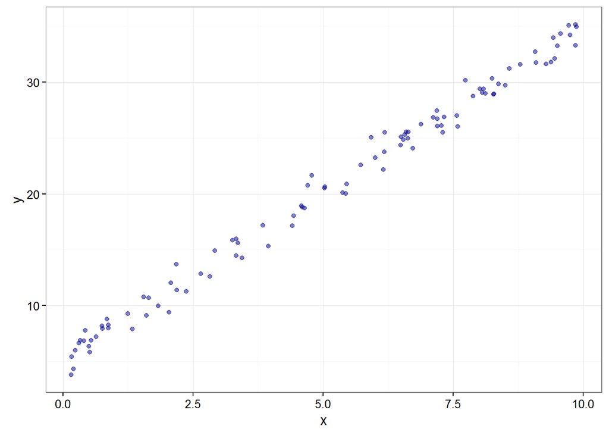

### Analytische Lösung des KQ-Schätzers

Für die Schätzung der Regressionskoeffizienten des linearen Modells wird die Methoden der kleinsten Quadrate (KQ-Methode) angewendet. Gemäß Annahme an ein lineares Regressionsmodell sind die Spalten der Designmatrix `design.mx` linear unabhängig. Fasst man nun das lineare Regressionsmodell als lineares Gleichungssystem auf, so lässt sich der KQ-Schätzer analytisch bestimmen. Der KQ-Schätzer ergibt sich als Lösung der sogenannten *Normalgleichung*. Die Funktion `solve()` liefert hierbei in **R** die Inverse einer quadratischen Matrix.

```r
theta.ana <- solve((t(design.mx) %*% design.mx)) %*% t(design.mx) %*% y
theta.ana
```

```
##        [,1]
## f0 5.245699
## f1 2.967013
```

In **R** wird die Berechnung durch die Funktion `lm()` (linear model) durchgeführt.

```r
lm.fit <- lm(y ~ f1,
             data=as.data.frame(cbind(y, design.mx)))

theta.lm <- c(as.numeric(lm.fit$coefficients[1]),
              as.numeric(lm.fit$coefficients[2]))
theta.lm
```

```
## [1] 5.245699 2.967013
```

### Gradientenverfahren

Eine alternative Möglichkeit für die Schätzung der Regressionskoeffizienten ist das Gradientenverfahren. Das Verfahren ist ein numerisches Verfahren, um allgemeine Optimierungsprobleme zu lösen. Das Verfahren wird laut [Wikipedia](https://de.wikipedia.org/wiki/Gradientenverfahren) auch das *Verfahren des steilen Abstiegs* gennant. In dem Machine Learning-Kurs von [Andrew Ng](https://www.coursera.org/learn/machine-learning/) wird das Verfahren ausführlich eingeführt und dort als *batch gradient descent-method* bezeichnet.

Für die Implementierung muss zuerst eine *cost function* definiert werden. Diese Funktion soll anschließend minimiert werden. Im Kontext der linearen Regression ist die `cost.function` durch die KQ-Methode definiert.

```r
cost.function <- function(X, y, theta){
  m <- length(y)
  h = X %*% theta
  J = 1/(2*m) * sum((h-y)^2)
  return(J)
}
```

Als weitere Inputfaktoren für die Durchführung der *batch gradient descent-method* sind die Anzahl der Iterationen `n.iter` und die Schrittweise (*learning rate*) `alpha` anzugeben. Ebenfalls wird ein Startwert `theta.dg` für die Durchführung der Optimierung anzugeben. In der Funktion `descent.gradient` werden iterativ die Startwerte von `theta` derart verändert, so dass die Kostenfunktion minimiert wird.

```r
descent.gradient <- function(X, y, theta.dg, alpha, n.iter){

  m <- length(y)
  J.hist <- rep(0, n.iter)
  t.hist <- matrix(0, nrow=n.iter+1, ncol=length(theta.dg))
  t.hist[1,] <- theta.dg

  for(i in 1:n.iter){

    h <- X %*% theta.dg

    theta.dg = theta.dg - alpha * (1/m) * (t(X) %*% (h-y))

    J.hist[i] <- cost.function(X, y, theta=theta.dg)
    t.hist[i+1,] <- theta.dg
  }

  Cost.hist <- data.frame(Iteration = seq(1:n.iter),
                       Cost = J.hist)

  Theta.hist <- as.data.frame(t.hist)
  colnames(Theta.hist) <- paste0("f", seq(0,length(theta.dg)-1))
  Theta.hist$Iteration <- seq(0, n.iter, 1)

  return(list(theta = theta.dg,
              Cost.hist = Cost.hist,
              Theta.hist = Theta.hist))
}
```

Die Anwendung des Gradientenverfahrens führt zu den nachfolgenden Ergebnissen.

```r
dg.result <- descent.gradient(X=design.mx, y=y, theta.dg=c(0,0), alpha=0.03, n.iter=1000)
dg.result$theta
```

```
##        [,1]
## f0 5.244057
## f1 2.967249
```

Die Konvergenz des Gradientenverfahrens lässt sich anhand des Verlaufs der Kostenfunktion darstellen.

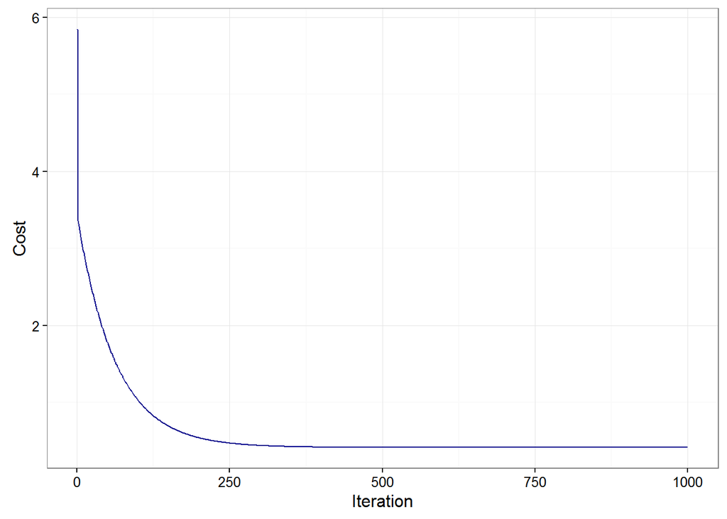

## Multivariate Regression

Die beiden oben vorgestellten Verfahren lassen sich auch für eine multivariate Regression verwenden. Die obigen Formeln sind bereits in Matrix-Schreibweise geschrieben, so dass sich diese ohne Anpassungen auch für höher dimensionale Designmatrizen anwenden lassen.

```r
theta.orig <- c(-4,7,8,2,-0.5)
m <- 100

design.mx <- as.matrix(cbind(
                              rep(1, m),
                              runif(m, -1, 1), runif(m, -1, 1),
                              runif(m, -1, 1), runif(m, -1, 1)))
colnames(design.mx) <- c("f0", "f1", "f2", "f3", "f4")

y = design.mx %*% theta.orig + rnorm(m)
```

Die analytische Lösung ergibt sich wieder als Lösung der *Normalgleichung*.

```r
theta.ana <- solve((t(design.mx) %*% design.mx)) %*% t(design.mx) %*% y
theta.ana
```

```
##          [,1]
## f0 -4.1186471
## f1  7.3079276
## f2  8.1282469
## f3  2.2244054
## f4 -0.3673481
```

Die Anwendung des Gradientenverfahrens erfolgt wieder durch die Funktion `descent.gradient`.

```r
dg.result <- descent.gradient(X=design.mx, y=y, theta.dg=c(0,0,0,0,0), alpha=0.03, n.iter=1000)
dg.result$theta
```

```
##          [,1]
## f0 -4.1186273
## f1  7.3077098
## f2  8.1279963
## f3  2.2242229
## f4 -0.3672782
```